# Kernel change point detection: a performance comparison

Info

- Try this notebook in an executable environment with [Binder](https://mybinder.org/v2/gh/deepcharles/ruptures/master?filepath=docs/examples/kernel-cpd-performance-comparison.ipynb).
- Download this notebook [here](https://github.com/deepcharles/ruptures/blob/master/docs/examples/kernel-cpd-performance-comparison.ipynb).

## Introduction

In `ruptures`, there are two ways to perform kernel change point detection:

- by using the pure Python classes Dynp (known number of change points) and Pelt (unknown number of change points),
- by using the faster class (implemented in C) KernelCPD which contains both the dynamic programming approach and the penalized approach (PELT).

This example illustrates the performance of the fast C implementation compared to the pure Python one.

The kernel change point detection setting is briefly described in the user guide. The interested reader can refer to [Celisse2018, Arlot2019] for a more complete introduction.

The list of available kernels is available here, but in this example we only consider two:

- the linear kernel, \(k_{\text{linear}}(x, y) = x^T y\) (Euclidean scalar product) and the induced norm is the Euclidean norm;
- the Gaussian kernel (also known as radial basis function, rbf), \(k_{\text{Gaussian}}(x,y)=\exp(-\gamma \|x-y\|^2)\) where \(\|\cdot\|\) is the Euclidean norm and \(\gamma>0\) is a user-defined parameter.

## Setup

First, we make the necessary imports and generate a toy signal

```
import time  # for execution time comparison

import matplotlib.pyplot as plt  # for display purposes

import ruptures as rpt  # our package
from ruptures.metrics import hausdorff

# generate signal
n_samples, dim, sigma = 500, 3, 3
n_bkps = 6  # number of breakpoints
signal, bkps = rpt.pw_constant(n_samples, dim, n_bkps, noise_std=sigma)
fig, ax_array = rpt.display(signal, bkps)
```

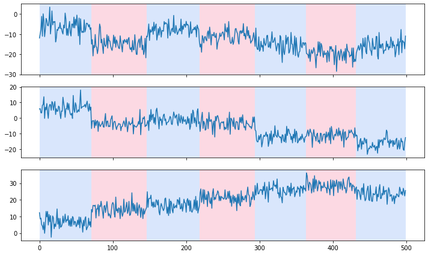

## Linear kernel

The linear kernel (see above) \(k_{\text{linear}}\) can detect changes in the mean of a signal. It also corresponds to the cost function `CostL2`.

### Dynamic programming

When the number of changes to detect is known beforehand, we use dynamic programming.

```
algo_python = rpt.Dynp(model="l2", jump=1, min_size=2).fit(
    signal
)  # written in pure python
algo_c = rpt.KernelCPD(kernel="linear", min_size=2).fit(signal)  # written in C

for (label, algo) in zip(
    ("Python implementation", "C implementation"), (algo_python, algo_c)
):
    start_time = time.time()
    result = algo.predict(n_bkps=n_bkps)
    print(f"{label}:\t{time.time() - start_time:.3f} s")
```

```
Python implementation:    6.770 s
C implementation:   0.008 s
```

The speed-up is quite significant and depends on the signal size (number \(T\) of samples and dimension \(d\)) and the number \(K\) of change points to detect. The C implementation has a time complexity of the order \(\mathcal{O}(KdT^2)\) and space complexity of the order \(\mathcal{O}(T)\). As to the Python implementation, the complexities in time and space are of the order \(\mathcal{O}(KdT^3)\) and \(\mathcal{O}(T^2)\) respectively.

We can also check that both methods return the same set of change points.

```
bkps_python = algo_python.predict(n_bkps=n_bkps)
bkps_c = algo_c.predict(n_bkps=n_bkps)
print(f"Python implementation:\t{bkps_python}")
print(f"C implementation:\t{bkps_c}")
print(f"(Hausdorff distance: {hausdorff(bkps_python, bkps_c):.0f} samples)")
```

```
Python implementation:    [71, 147, 218, 294, 364, 433, 500]
C implementation:   [71, 147, 218, 294, 364, 433, 500]
(Hausdorff distance: 0 samples)
```

### PELT

When the number of changes to detect is unknown, we resort to PELT [Killick2012] to solve the penalized detection problem.

```
algo_python = rpt.Pelt(model="l2", jump=1, min_size=2).fit(
    signal
)  # written in pure python
algo_c = rpt.KernelCPD(kernel="linear", min_size=2).fit(
    signal
)  # written in C, same class as before


penalty_value = 100  # beta

for (label, algo) in zip(
    ("Python implementation", "C implementation"), (algo_python, algo_c)
):
    start_time = time.time()
    result = algo.predict(pen=penalty_value)
    print(f"{label}:\t{time.time() - start_time:.3f} s")
```

```
Python implementation:    0.508 s
C implementation:   0.001 s
```

Again, the speed-up is quite significant and depends on the signal size (number \(T\) of samples and dimension \(d\)) and the penalty value \(\beta\). We remark that, for both Python and C implementations, PELT is more efficient then dynamic programming.

We can also check that both methods return the same set of change points.

```
bkps_python = algo_python.predict(pen=penalty_value)
bkps_c = algo_c.predict(pen=penalty_value)
print(f"Python implementation:\t{bkps_python}")
print(f"C implementation:\t{bkps_c}")
print(f"(Hausdorff distance: {hausdorff(bkps_python, bkps_c):.0f} samples)")
```

```
Python implementation:    [71, 147, 153, 219, 222, 294, 364, 433, 500]
C implementation:   [71, 147, 153, 219, 222, 294, 364, 433, 500]
(Hausdorff distance: 0 samples)
```

Note

By default, `Dynp` and `Pelt` has `jump=5`. In `KernelCPD`, `jump=1` and cannot be changed. This is because, in the C implementation, changing the `jump` does not improve the running time significatively, while it does in the Python implementation.

## Gaussian kernel

The Gaussian kernel (see above) \(k_{\text{Gaussian}}\) can detect changes in the distribution of an i.i.d. process. This is a feature of several kernel functions (in particular *characteristics* kernels; see [Gretton2012] for more information). It also corresponds to the cost function `CostRbf`.

### Dynamic programming

When the number of changes to detect is known beforehand, we use dynamic programming.

```
params = {"gamma": 1e-2}
algo_python = rpt.Dynp(model="rbf", params=params, jump=1, min_size=2).fit(
    signal
)  # written in pure python
algo_c = rpt.KernelCPD(kernel="rbf", params=params, min_size=2).fit(
    signal
)  # written in C

for (label, algo) in zip(
    ("Python implementation", "C implementation"), (algo_python, algo_c)
):
    start_time = time.time()
    result = algo.predict(n_bkps=n_bkps)
    print(f"{label}:\t{time.time() - start_time:.3f} s")
```

```
Python implementation:    7.679 s
C implementation:   0.014 s
```

Again, the speed-up is quite significant. The C implementation has a time complexity of the order \(\mathcal{O}(CKT^2)\) and space complexity of the order \(\mathcal{O}(T)\), where \(C\) is the complexity of computing \(k(y_s, y_t)\) once. As to the Python implementation, the complexities in time and space are of the order \(\mathcal{O}(CKT^4)\) and \(\mathcal{O}(T^2)\) respectively.

We can also check that both methods return the same set of change points.

```
bkps_python = algo_python.predict(n_bkps=n_bkps)
bkps_c = algo_c.predict(n_bkps=n_bkps)
print(f"Python implementation:\t{bkps_python}")
print(f"C implementation:\t{bkps_c}")
print(f"(Hausdorff distance: {hausdorff(bkps_python, bkps_c):.0f} samples)")
```

```
Python implementation:    [71, 147, 218, 294, 364, 433, 500]
C implementation:   [71, 147, 218, 294, 364, 433, 500]
(Hausdorff distance: 0 samples)
```

Note

If not provided by the user, the `gamma` parameter is chosen using the median heuristics, meaning that it is set to inverse of the median of all pairwise products \(k(y_s, y_t)\).

### PELT

When the number of changes to detect is unknown, we resort to PELT to solve the penalized detection problem.

```
algo_python = rpt.Pelt(model="rbf", jump=1, min_size=2).fit(
    signal
)  # written in pure python
algo_c = rpt.KernelCPD(kernel="rbf", min_size=2).fit(
    signal
)  # written in C, same class as before


penalty_value = 1  # beta

for (label, algo) in zip(
    ("Python implementation", "C implementation"), (algo_python, algo_c)
):
    start_time = time.time()
    result = algo.predict(pen=penalty_value)
    print(f"{label}:\t{time.time() - start_time:.3f} s")
```

```
Python implementation:    0.277 s
C implementation:   0.002 s
```

Again, the speed-up is quite significant and depends on the signal size (number \(T\) of samples and dimension \(d\)) and the penalty value \(\beta\). We remark that, for both Python and C implementations, PELT is more efficient then dynamic programming.

We can also check that both methods return the same set of change points.

```
bkps_python = algo_python.predict(pen=penalty_value)
bkps_c = algo_c.predict(pen=penalty_value)
print(f"Python implementation:\t{bkps_python}")
print(f"C implementation:\t{bkps_c}")
print(f"(Hausdorff distance: {hausdorff(bkps_python, bkps_c):.0f} samples)")
```

```
Python implementation:    [71, 147, 218, 294, 364, 433, 500]
C implementation:   [71, 147, 218, 294, 364, 433, 500]
(Hausdorff distance: 0 samples)
```

## References

[Gretton2012] Gretton, A., Borgwardt, K. M., Rasch, M. J., Schölkopf, B., & Smola, A. (2012). A kernel two-sample test. The Journal of Machine Learning Research, 13, 723–773.

[Killick2012] Killick, R., Fearnhead, P., & Eckley, I. (2012). Optimal detection of changepoints with a linear computational cost. Journal of the American Statistical Association, 107(500), 1590–1598.

[Celisse2018] Celisse, A., Marot, G., Pierre-Jean, M., & Rigaill, G. (2018). New efficient algorithms for multiple change-point detection with reproducing kernels. Computational Statistics and Data Analysis, 128, 200–220.

[Arlot2019] Arlot, S., Celisse, A., & Harchaoui, Z. (2019). A kernel multiple change-point algorithm via model selection. Journal of Machine Learning Research, 20(162), 1–56.